# FordGoBike DataSet

## (Jan 2018 - Dec 2018)

## **Introduction**

> Ford GoBike is the Bay Area's bike share system. Bay Area Bike Share was introduced in 2013 as a pilot program for the region, with 700 bikes and 70 stations across San Francisco and San Jose. Once expansion is complete, Ford GoBike will grow to 7,000 bikes across San Francisco, the East Bay and San Jose.

> Ford GoBike, like other bike share systems, consists of a fleet of specially designed, sturdy and durable bikes that are locked into a network of docking stations throughout the city. The bikes can be unlocked from one station and returned to any other station in the system, making them ideal for one-way trips. People use bike share to commute to work or school, run errands, get to appointments or social engagements and more. It's a fun, convenient and affordable way to get around.

> The bikes are available for use 24 hours/day, 7 days/week, 365 days/year and riders have access to all bikes in the network when they become a member or purchase a pass.

> See the data [here](https://www.fordgobike.com/system-data)

## Univariate Exploration

> In this section, I investigate distributions of individual variables. This is also in preparation to look at the relationships between variables.

### Question 1:

#### When is the service often used? (weekdays vs. weekends) ?

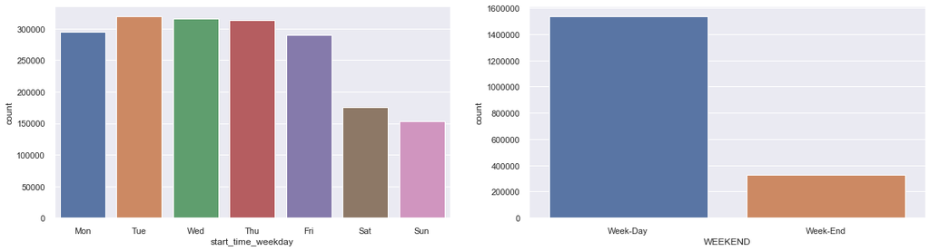

```python
df['WEEKEND'] = ((pd.DatetimeIndex(df['start_time']).dayofweek) // 5 == 1).astype(float)
weekday = ['Mon', 'Tue', 'Wed', 'Thu', 'Fri', 'Sat', 'Sun']
df['WEEKEND'] = df['WEEKEND'].map({0.0: 'Week-Day', 1.0: 'Week-End'})
sns.set(style="darkgrid")
fig, ax =plt.subplots(1,2,figsize=(20,5))
sns.countplot(df['start_time_weekday'], ax=ax[0],order = weekday)
sns.countplot(df['WEEKEND'], ax=ax[1])
fig.show()
```

##### Observed :

##### Tuesdays and Wednesdays seem to be the most popular days for using the bike sharing system. The usage drops significantly on Saturdays and Sundays suggesting the Ford bike share system is used primarily for commuting purposes during working days.

### Question 2:

#### Which Month seem to be the most popular Month for using the bike sharing system ?

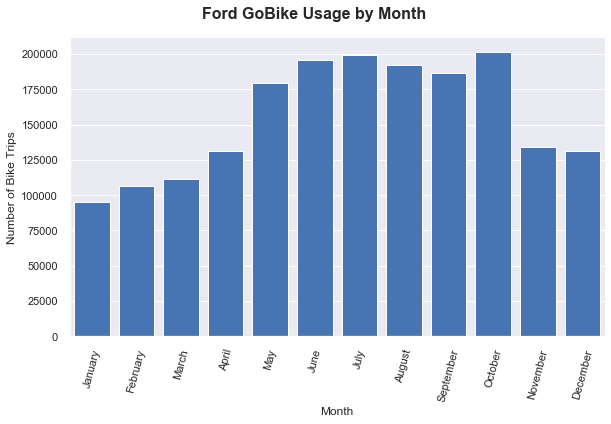

```python
# Monthly usage of the Ford Go Bike system
graph = sns.catplot(data = df, x = 'start_time_month', kind = 'count', color = no_color, aspect = 1.7);
graph.set_axis_labels('Month', 'Number of Bike Trips'),
graph.fig.suptitle('Ford GoBike Usage by Month', y = 1.05, fontsize = 16, fontweight = 'bold');
graph.set_xticklabels(rotation=75);
```

##### Observed :

##### Not surprisingly, the summer months and early-mid autumn are the most popular times to use the Ford Go Bike sharing system. October is the most popular month, with July as the second most popular, and June/August coming in closely as the third most popular months to use the bike system

### Question 3:

#### What time of the day do users use this service?

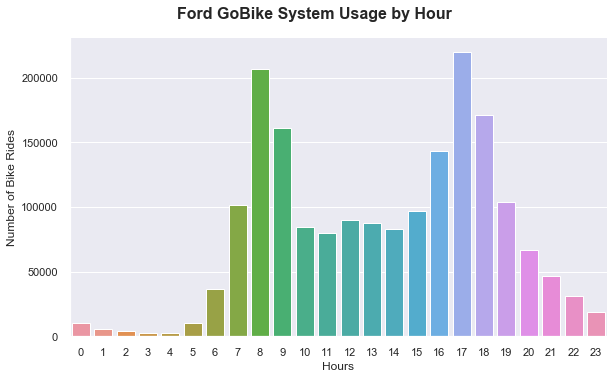

```python
# Hourly usage of the Ford Go Bike System
graph = sns.catplot(data = df, x='start_time_hour', kind='count', aspect = 1.7)
graph.set_axis_labels('Hours', 'Number of Bike Rides')
graph.fig.suptitle('Ford GoBike System Usage by Hour', y=1.05, fontsize=16, fontweight='bold');
```

##### Observed :

##### Most usage of bike is during the morning hours of 8-9am, and in the afternoon hours of 5-6pm, which is a typical workday .

### Question 4:

#### Average Duration of ride ?

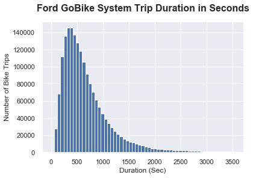

```python
# Duration of the bike rides - in SECONDS
bin_edges = np.arange(0, 3600, 60)
plt.hist(data = df, x = 'duration_sec', bins = bin_edges);
plt.title("Ford GoBike System Trip Duration in Seconds", y=1.05, fontsize=16, fontweight='bold')
plt.xlabel('Duration (Sec)')
plt.ylabel('Number of Bike Trips');
```

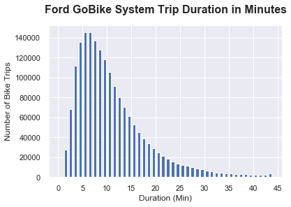

```python
# Duration of the bike rides -in MINUTES
bin_edges = np.arange(0, 45, 1)
ticks = [0, 5, 10, 15, 20, 25, 30,  35, 40, 45]
labels = ['{}'.format(val) for val in ticks]
plt.hist(data = df, x = 'duration_min', bins = bin_edges, rwidth = 0.6);
plt.title("Ford GoBike System Trip Duration in Minutes", y=1.05, fontsize=16, fontweight='bold')
plt.xlabel('Duration (Min)')
plt.xticks(ticks, labels)
plt.ylabel('Number of Bike Trips');
```

### Question 4:

#### Average Distance Travel ?

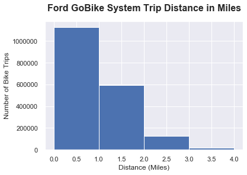

```python
# Distance in miles traveled
bin_edges = np.arange(0, 5, 1)
plt.hist(data = df, x = 'distance_miles', bins = bin_edges);
plt.title("Ford GoBike System Trip Distance in Miles", y=1.05, fontsize=16, fontweight='bold')
plt.xlabel('Distance (Miles)')
plt.ylabel('Number of Bike Trips');
```

## Bivariate Exploration

> In this section, I investigate relationships between pairs of variables in the data.

### What are the characteristics of Customers vs. Subscribers?

### Question 5:

#### Who's contribution is high the Customer are the Subscriber ?

[figure not shown]

```python
# Customers vs Subscribers Visuals # pie chart
plt.figure(figsize = [8, 5])
labels = ['Customer', 'Subscriber']
size = [customer_prop, subscriber_prop]
explode = (0, 0.3)
plt.pie(size, explode=explode, labels = labels, autopct='%1.1f%%', shadow=True, startangle=90, textprops={'color':'white'})
plt.axis('equal')
plt.suptitle('Ford GoBike System - Customers vs. Subscribers', y=1.05, fontsize=16, fontweight='bold');
```

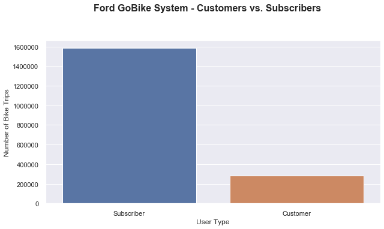

```python
# Customers vs Subscribers Visuals # bar chart
plt.figure(figsize = [10, 5])
graph = sns.countplot(data = df, x = "user_type", order = df.user_type.value_counts().index);
graph.set_xlabel('User Type');
graph.set_ylabel('Number of Bike Trips');
plt.suptitle('Ford GoBike System - Customers vs. Subscribers', y=1.05, fontsize=16, fontweight='bold');
```

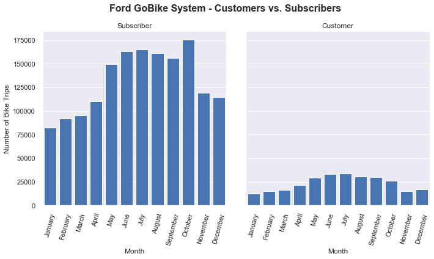

```python
# Customer Usage by Month vs. Subscriber Usage by Month
graph = sns.catplot(data=df, x='start_time_month', col="user_type", kind='count', sharey = True, color = no_color);
graph.set_axis_labels("Month", "Number of Bike Trips");
graph.set_titles("{col_name}");
graph.fig.suptitle('Ford GoBike System - Customers vs. Subscribers', y=1.05, fontsize=16, fontweight='bold');
graph.set_xticklabels(rotation=75);
```

##### Observed :

##### Winter months are the worst for the bike sharing system for both groups what can be determined by the harsher weather.

##### Customers: demand is high around summertime, reaching its peak in July.

##### Subscribers: the highest demand is from May till October, reaching it's peak in October.

### Question 6:

#### Who travel more is customers are subscribers ?

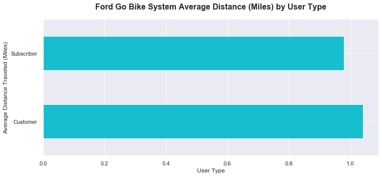

```python
# Customer Usage by Distance vs. Subscriber Usage by Distance
plt = df.groupby('user_type')['distance_miles'].mean().plot(kind='barh', figsize=(12,5),color='#17becf');
plt.set_title('Ford Go Bike System Average Distance (Miles) by User Type', y=1.05, fontsize=16, fontweight='bold')
plt.set_xlabel('User Type')
plt.set_ylabel('Average Distance Traveled (Miles)');
```

##### Observed :

##### The average distance traveled by customers is slightly higher than subscribers. The commuting distance for the subscribers is less than the average ride a customer takes.

### Question 7:

#### Customer vs Subscriber ride duration ?

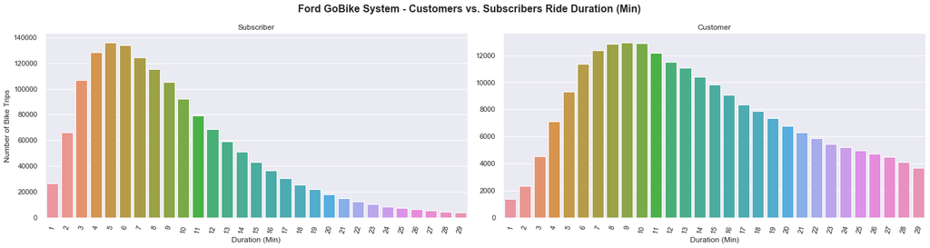

```python
# Customer Usage by Duration vs. Subscriber Usage by Duration
data = df.query('duration_min < 30')
graph = sns.catplot(data=data, x = 'duration_min', col='user_type', kind='count', sharey = False, height=5, aspect=2);
graph.set_axis_labels('Duration (Min)', 'Number of Bike Trips')
graph.set_titles('{col_name}')
graph.fig.suptitle('Ford GoBike System - Customers vs. Subscribers Ride Duration (Min)', y=1.05, fontsize=16, fontweight='bold');
graph.set_xticklabels(rotation=75);
```

### Question 8:

#### Customer vs Subscriber Usage of bike system ?

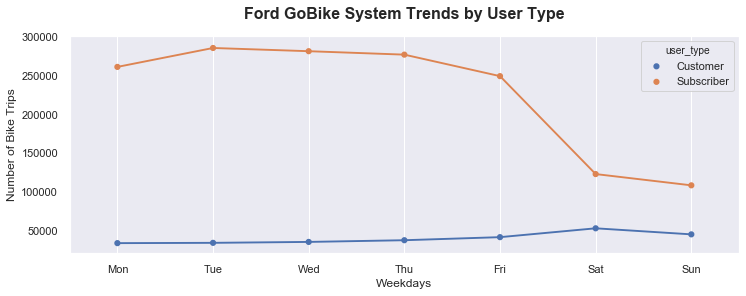

```python
# Customer Usage by Weekday vs. Subscriber Usage by Weekday
plt.figure(figsize=(12, 4))
df_cleaned_user_week = df.groupby(['start_time_weekday', 'user_type']).size().reset_index()
weekday = ['Mon', 'Tue', 'Wed', 'Thu', 'Fri', 'Sat', 'Sun']
ax = sns.pointplot(data=df_cleaned_user_week, x='start_time_weekday', y=0, hue = 'user_type', scale=.7, order = weekday);
plt.title('Ford GoBike System Trends by User Type', y=1.05, fontsize=16, fontweight='bold')
plt.xlabel('Weekdays')
plt.ylabel('Number of Bike Trips');
plt.grid()
```

##### Observed :

##### The point plot above is an excellent visual showing the sharp contrast between Customers and Subscribers. Customers have a relatively low usage of the bike share system with a small increase on the weekends. Subscribers are the opposite - there is steadily high usage on weekdays, with a sharp decline on the weekend.

## Conclusion

> Tuesdays and Wednesdays seem to be the most popular days for using the bike sharing system. The usage drops significantly on Saturdays and Sundays

> The summer months and early-mid autumn are the most popular times to use the Ford Go Bike sharing system. October is the most popular month, with July as the second most popular, and June/August coming in closely as the third most popular months to use the bike system

> Most usage of bike is during the morning hours of 8-9am, and in the afternoon hours of 5-6pm, which is a typical workday .

> Winter months are the worst for the bike sharing system Customers: demand is high around summertime, reaching its peak in July.  
> Subscribers: the highest demand is from May till October, reaching it's peak in October.

> The average distance traveled by customers is slightly higher than subscribers. The commuting distance for the subscribers is less than the average ride a customer takes.

## Summary

Ford GoBike System is one of the best program which help users physics and environment friendly

> Apart from dataset Environmentally friendly, budget friendly, and lifetsyle friendly.  
> Subscribers (i.e. daily commuters) benefit from a health commuting choice  
> Customers (i.e. tourists, students, etc.) have a sustainable, yet flexible option for touring the city.  
> Affordable and convenient transportation for the people of all socioeconomic classes